# Statistics

# 1 Definitions

## 1.1 Distributions

- Normal distribution
  - Positive
  - Negative
- Skew
- Kurtosis
  - Leptokurtic
  - Platykurtic
- Mode

Median Mean

$$\bar{X} = \frac{\sum_{i=1}^n x_i}{n}$$
z-score

$$z = \frac{X - \bar{X}}{s}$$

## 1.2 Variables

- Independent: causes the effect, or predictor variable. Its value does not depend on any other variable.
- Dependent: the effect, or outcome variable. It depends on the independent variable.
- Categorical: distinct entities (categories).
  - Binary: two categories.
  - Nominal: numbers represent category names.
  - Ordinal: ordered nominal data.
- Continuous: numeric value on a measurement scale.
  - Interval: a scale with equal intervals between possible values.
  - Ratio: ratio of values is meaningful (scale has a zero point).
  - Discrete: only certain allowed variables in the scale.
- Confounding: a variable other than the predictor that may affect the outcome.

## 1.3 Data collection methods

- Correlational or cross-sectional research: observational without interference/manipulation.
- Experimental research: variable(s) is manipulated and its effect measured.

# 2 Exploring data

Parametric tests are based on the normal distribution. There are four assumptions.

1. Normally distributed.
2. Homogeneity of variance.
3. Interval variables are used.
4. Independence. Samples do not influence each other.

```r
library(tidyverse)
# dlf <- read.delim("DownloadFestival.dat", header = TRUE)
# #Remove the outlier from the day1 hygiene score
# dlf$day1 <- ifelse(dlf$day1 > 20, NA, dlf$day1)
# write.csv(dlf, file = 'input_1.csv', row.names = FALSE)

df <- read_csv(file = 'input_1.csv')
head(df)
```

```
## # A tibble: 6 x 5
##   ticknumb gender  day1  day2   day3
##      <dbl> <chr>  <dbl> <dbl>  <dbl>
## 1     2111 Male    2.64  1.35  1.61
## 2     2229 Female  0.97  1.41  0.290
## 3     2338 Male    0.84 NA    NA
## 4     2384 Female  3.03 NA    NA
## 5     2401 Female  0.88  0.08 NA
## 6     2405 Male    0.85 NA    NA
```

## 2.1 Histograms

In a density histogram the area of each bin equals its relative frequency, and the area of the entire histogram is one.

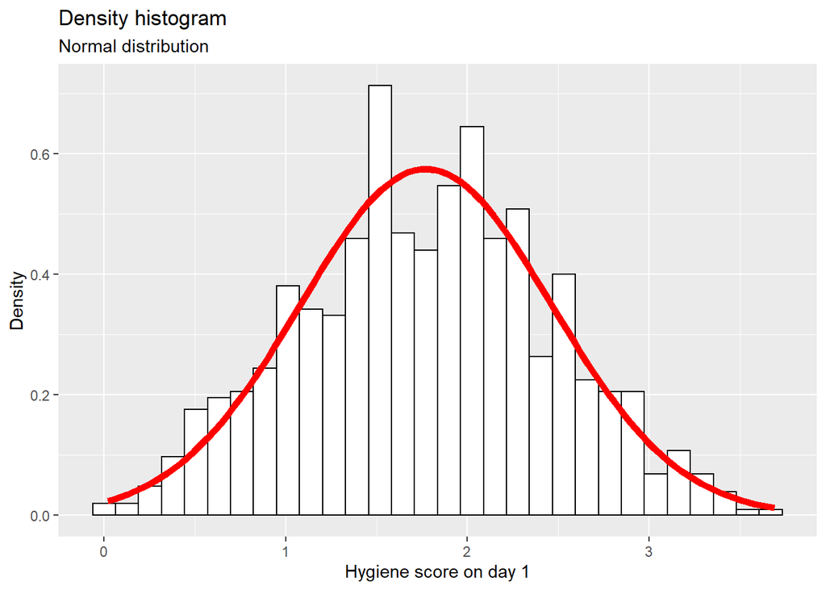

```r
p <- ggplot(df, aes(day1)) +
  geom_histogram(aes(y = ..density..), colour = 'black', fill = 'white') +
  labs(x = 'Hygiene score on day 1', y = 'Density', title = 'Density histogram', subtitle = 'Normal distribution') +
  stat_function(fun = dnorm,
                args = list(mean = mean(df$day1, na.rm = TRUE),
                            sd = sd(df$day1, na.rm = TRUE)),
                colour = 'red', size = 2)
p
```

One day1 value (ticknumb 4158) is removed because it is NA.

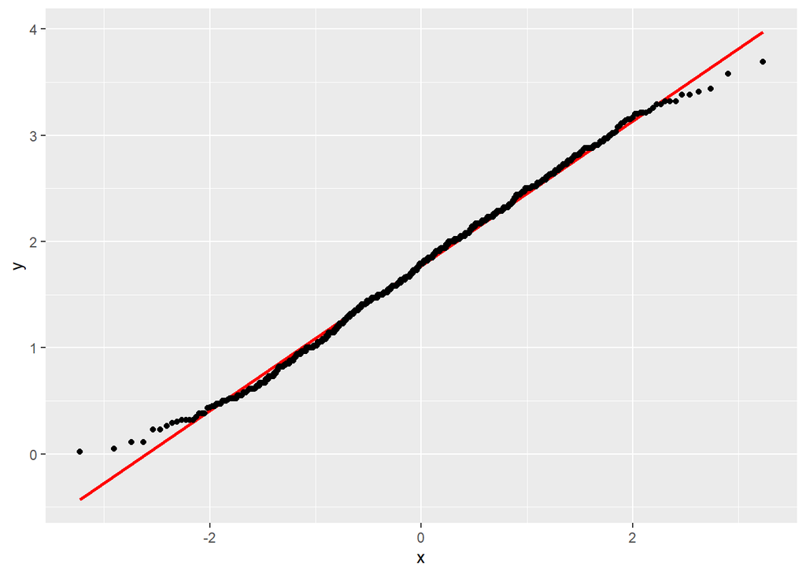

```r
p <- ggplot(df, aes(sample = day1))
p + stat_qq_line(color = 'red', size = 1) + stat_qq()
```